# Problem Set 2. Incomplete Markets

Author: Yuxuan Zhao

The answer of Q4 is after Prof. Amador's initial code.

## Initial setup

```python
%matplotlib inline
import numpy as np
from matplotlib import pyplot as plt
import matplotlib as mpl
mpl.rc("savefig", dpi=120)
import numba as nb
import time
```

## Parameters and grids

```python
beta= 0.95
bigR = 1.04   # gross interest rate
rho = 2
phi = 0
w = 1
n = 2 # number of endowment shocks
p = np.array([[.5, .5],
              [0.2, 0.8]])  # transition probability for the endowment shocks
l_g = np.array([0.5, 1.0]) # endowment shocks
y_g = w * l_g

ytilde_g = y_g - (bigR - 1) * phi

grid_points = 10000 # for the asset holdings
ahat_max = 15  # this is just a guess
ahat_min = 0
ahat_g = np.linspace(ahat_min, ahat_max, grid_points) # grid for ahat
```

```python
rbar=1/beta - 1
print("rbar: ", rbar)
```

```
rbar:  0.05263157894736836
```

## Solving the HH problem

The following function (iterate_value) compues the value function and the policy function from the HH problem. It is smarter than brute force value function iteration as it exploits that the policy function is monotonic and the the problem is concave.

```python
@nb.jit
def u(c):
    return c ** (1 - rho) / (1 - rho)

@nb.jit
def iterate_value(v_0, bigR, ytilde_g, tolerance=10**(-4)):
    v_1 = np.empty((grid_points, n))
    pol_1 = np.empty((grid_points, n), dtype=np.int32)
    p_transpose = p.transpose()
    beta_v_exp = np.empty((grid_points, n))
    iter = 0
    while True:
        distance = 0.0
        iter += 1
        for s in range(n):  # pre-computing the expected value term
            for i in range(grid_points):
                accum = 0.0
                for sprime in range(n):
                    accum = accum + beta * p[s, sprime] * v_0[i, sprime]
                beta_v_exp[i, s] = accum
        for s in range(n):  # doing the optimization
            pol = 0
            for i in range(grid_points):
                just_started = True
                j = pol # policy is monotonic -- start from the previous optimal policy
                while j < grid_points:
                    c = bigR * ahat_g[i] + ytilde_g[s] - ahat_g[j]
                    if c > 0.0:
                        temp = u(c) + beta_v_exp[j, s]
                        if just_started:
                            vmax = temp
                            pol = j
                            just_started = False
                        elif temp > vmax:
                            vmax = temp
                            pol = j
                        else:
                            # value decreased -- concavity means it can't go up again
                            break
                    j += 1
                v_1[i, s] = vmax
                pol_1[i, s] = pol
                dis = abs(vmax - v_0[i, s])
                if dis > distance:
                    distance = dis
        if distance < tolerance:
            break
        else:
            temp2 = v_0
            v_0 = v_1
            v_1 = temp2
    return v_1, pol_1
```

### Computing the solution to the HH's problem

```python
v_0 = np.zeros((grid_points, n))
t = time.time()
value, policy = iterate_value(v_0, bigR, ytilde_g)
print(' {} seconds'.format(time.time() - t))
```

```
 0.5308690071105957 seconds
```

### Plotting the Transition maps

Because the state matters now (the shocks are not iid), we have two plots for the transition map of Aiyagari (one for each idiosyncratic state)

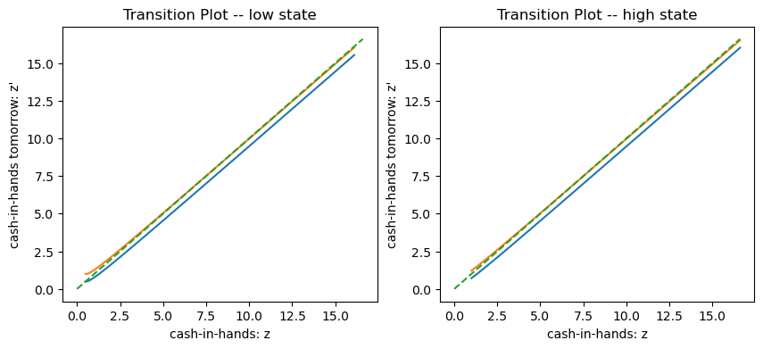

```python
plt.figure(figsize=(10, 4))
for plot_i, label in ((0, 'low'), (1, 'high')):
    plt.subplot(121 + plot_i)
    plt.title("Transition Plot -- " + label + " state")
    state = plot_i
    zmax = bigR * ahat_max + max(y_g)
    for s in range(n):
        plt.plot(
            [bigR * ahat_g[i] + ytilde_g[state] for i in range(grid_points)],
            [bigR * ahat_g[policy[i, state]] + ytilde_g[s] for i in range(grid_points)])
    plt.plot((0, zmax), (0, zmax), '--')
    plt.ylabel("cash-in-hands tomorrow: z'")
    plt.xlabel("cash-in-hands: z")
```

## The stationary distribution

The following function takes an initial pdf and iterates using the policy function to obtain the stationary distribution

```python
@nb.jit
def get_stationary_distribution(pdf_0, policy, tolerance=10**(-7)):
    while True:
        pdf_1 = np.zeros((grid_points, n))
        for i in range(grid_points):
            for s in range(n):
                for sprime in range(n):
                    pdf_1[policy[i, s], sprime] += p[s, sprime] * pdf_0[i, s]
        distance = 0.0
        for i in range(grid_points):
            for s in range(n):
                distance = max(abs(pdf_1[i, s] - pdf_0[i, s]), distance)
        if distance - tolerance < 0:
            break
        else:
            pdf_0 = pdf_1
    return pdf_1
```

### Computing the stationary distribution

```python
pdf_0 = np.ones((grid_points, n)) / (grid_points * n)
t = time.time()
pdf_ss = get_stationary_distribution(pdf_0, policy)
print(' {} seconds'.format(time.time() - t))
```

```
 0.14415431022644043 seconds
```

### Plotting the Stationary distribution over assets

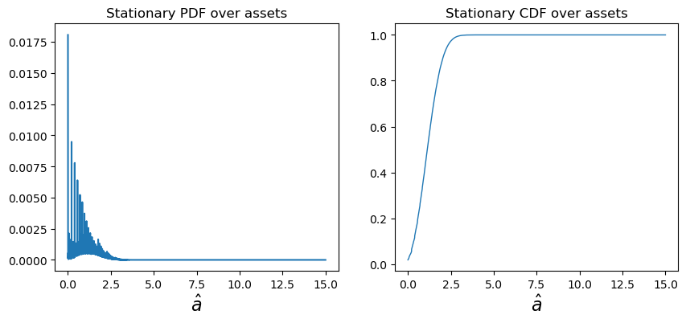

```python
plt.figure(figsize=(10, 4))
plt.subplot(121)
pdf_assets = np.zeros((grid_points))
for i in range(grid_points):
        pdf_assets[i] = np.sum(pdf_ss[i, :])
plt.plot(ahat_g, pdf_assets)
plt.xlabel('$\hat{a}$', fontsize=16)
plt.title('Stationary PDF over assets');

plt.subplot(122)
plt.plot(ahat_g, np.cumsum(pdf_assets), lw = 1)
plt.xlabel('$\hat{a}$', fontsize=16)
plt.title('Stationary CDF over assets');
```

## Problem 4

### (a) Natural borrowing limit

We know that $R=1.04$, the natural borrowing limit is $$ \phi=-\frac{w l_{\min}}{R-1}=-\frac{0.5}{0.04}=-12.5 $$

```python
r = bigR - 1
y_min = w * np.min(l_g)
a_natural = - y_min / r
print("Natural borrowing limit (conceptual): a >= {:.4f}".format(a_natural))
print("But the problem imposes phi = 0, so the implemented constraint is a' >= 0.")
```

```
Natural borrowing limit (conceptual): a >= -12.5000
But the problem imposes phi = 0, so the implemented constraint is a' >= 0.
```

### (b) Numerical Method of Solving HH problem

The code solves a standard income-fluctuation (Aiyagari) household problem.

Let the state be $(a,s)$. The Bellman equation is $$ V(a,s)=\max \left\{ u(c)+\beta\sum_{s'\in S}p_{ss'}V(a',s') \right\}, $$ subject to $$ a'\ge -\phi \\ c+a' = Ra + y(s). $$

To remove the lower bound $a\ge -\phi$ from the choice set, define shifted variables $$ \hat a \equiv a+\phi $$ Then the constraints become $$ a\ge -\phi \iff \hat a\ge 0 $$

Therefore the original problem is equivalent to a new Bellman equation:

$$ V(\hat a,s) = \max \left\{ u\big(c\big) +\beta\sum_{s'\in S} p_{ss'}\,V(\hat a',s') \right\}, $$ where $$ \hat a' \geq 0 \\ c + \hat a'= R \hat a + \tilde y(s) \\ \tilde y(s)=y(s)-(R-1)\phi. $$

We use VFI to solve this HH problem

Each VFI step does two key things:

#### 1. Precompute continuation values

For each current shock $s$ and each candidate next-asset index $j$, compute once: $$ \beta\,\mathbb E\!\left[V(\hat a_j,s')\mid s\right] =\beta\sum_{s'\in S}p_{ss'}\,V(\hat a_j,s'). $$ This avoids recomputing the expectation inside the inner maximization loop.

#### 2. Maximize over $j$ efficiently (monotonicity + “break on decline”)

Fix a shock $s$ and a current grid point $\hat a_i$. The code maximizes over next-asset grid indices $j$ the discrete objective $$ \Psi_{i,s}(j) \equiv u\!\left(c_{i,s}(j)\right) +\beta\sum_{s'\in S}p_{ss'}\,V(\hat a_j,s'), \qquad c_{i,s}(j)=R\hat a_i+\tilde y(s)-\hat a_j, $$ subject to feasibility $c_{i,s}(j)\ge 0$ (equivalently $\hat a_j\le R\hat a_i+\tilde y(s)$).

Let $j^*(i,s)\in\arg\max_j \Psi_{i,s}(j)$.

**Monotone search (start from previous maximizer).**
A standard property in this problem is that the optimal saving policy is increasing in cash-on-hand / assets, so the index policy is nondecreasing: $$ j^*(i+1,s)\ \ge\ j^*(i,s). $$ Therefore, when moving from $\hat a_i$ to $\hat a_{i+1}$ (holding $s$ fixed), the code starts the search at $$ j_{\text{start}} = j^*(i,s), $$ instead of restarting from $j=0$.

**Early stopping (“break on decline”).**
As $j$ increases, current consumption $c_{i,s}(j)$ falls, while the continuation term rises at a diminishing rate; numerically $\Psi_{i,s}(j)$ is typically single-peaked in $j$ (unimodal). The code exploits this by stopping once the objective begins to fall: $$ \text{if }\Psi_{i,s}(j+1) < \Psi_{i,s}(j)\text{ at some }j,\ \text{then stop searching larger }j. $$ Under unimodality, once the objective decreases it will not exceed the current best again, so the maximizer has already been passed.

Given an optimal policy $j^*(i,s)$, the economy becomes a finite-state Markov chain over states $(i,s)$. If $\mu_t(i,s)$ is the cross-sectional distribution, the forward update is: $$ \mu_{t+1}(j^*(i,s),s') \;+=\; p_{ss'}\,\mu_t(i,s)\qquad\text{for all }s'\in S. $$ Iterating this “push-forward” map until convergence yields the stationary distribution $\mu$. Marginal distributions (PDF/CDF over assets) are obtained by summing over $s$: $$ \mu_{\hat a}(i)=\sum_{s\in S}\mu(i,s). $$

### (c) Policy functions (assets and consumption) as functions of cash-in-hands

For each current employment state $s$, cash-in-hands is $z=R\hat a + y_s$. The code below plots $a'(z,s)$ and $c(z,s)$.

From the asset policy plot $a'(z,s)$, for a given level of cash-on-hand $z$ the household typically chooses **higher savings when unemployed**

**Why?**

Because the income process is persistent, Thus, at the same $z$, unemployment means lower current resources going forward and a higher chance of binding the borrowing constraint, so the household wants to save more (“precautionary saving”), shifting $a'(z,\text{unemployed})$ upward relative to $a'(z,\text{employed})$.

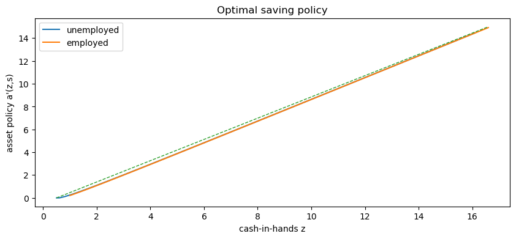

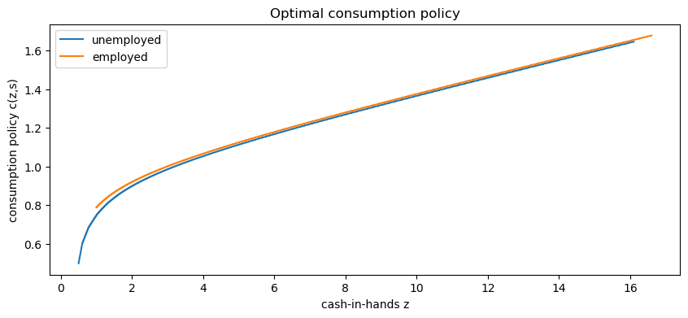

```python
# Build cash-in-hands grids by current state s
z_g = np.empty((grid_points, n))
a_prime = np.empty((grid_points, n))
c_pol = np.empty((grid_points, n))
for s in range(n):
    z_g[:, s] = bigR * ahat_g + ytilde_g[s]
    a_prime[:, s] = ahat_g[policy[:, s]]
    c_pol[:, s] = z_g[:, s] - a_prime[:, s]

plt.figure(figsize=(10,4))
for s,label in ((0,"unemployed"), (1,"employed")):
    plt.plot(z_g[:,s], a_prime[:,s], label=label)
plt.plot([z_g.min(), z_g.max()], [ahat_min, ahat_max], '--', lw=1)
plt.xlabel("cash-in-hands z")
plt.ylabel("asset policy a'(z,s)")
plt.title("Optimal saving policy")
plt.legend()

plt.figure(figsize=(10,4))
for s,label in ((0,"unemployed"), (1,"employed")):
    plt.plot(z_g[:,s], c_pol[:,s], label=label)
plt.xlabel("cash-in-hands z")
plt.ylabel("consumption policy c(z,s)")
plt.title("Optimal consumption policy")
plt.legend()
```

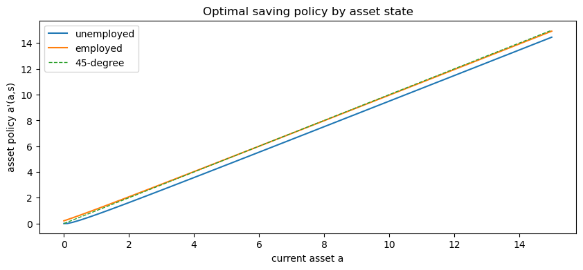

```python
# Build a'(a,s): x-axis is current asset a, y-axis is next-period asset a'
a_prime_a = np.empty((grid_points, n))
for s in range(n):
    a_prime_a[:, s] = ahat_g[policy[:, s]]

plt.figure(figsize=(10,4))
for s, label in ((0, "unemployed"), (1, "employed")):
    plt.plot(ahat_g, a_prime_a[:, s], label=label)

# optional: 45-degree line a' = a
plt.plot([ahat_g.min(), ahat_g.max()],
         [ahat_g.min(), ahat_g.max()],
         '--', lw=1, label="45-degree")

plt.xlabel("current asset a")
plt.ylabel("asset policy a'(a,s)")
plt.title("Optimal saving policy by asset state")
plt.legend()
plt.show()
```

### (d) Total asset holdings in the stationary distribution

Compute $\bar A=\int \hat a\, dF(\hat a,s)$ using the discrete stationary distribution from the code.

```python
Abar = np.sum(ahat_g[:,None] * pdf_ss)
print("Total (mean) asset holdings in the stationary distribution: {:.6f}".format(Abar))
```

```
Total (mean) asset holdings in the stationary distribution: 1.169336
```

### (e) Fraction borrowing constrained

With $\phi=0$, the borrowing constraint binds when the optimal choice is $a'(z,s)=0$ (the lowest grid point).

The fraction borrowing constrained is the stationary mass at the lower bound $a'=0$: $$ \Pr(a'=0)=\sum_i\sum_{s}\mu(i,s)\,\mathbf 1\{a'(z_i,s)=0\}. $$ In the code this comes out to about $1.8\%$

This is lower than I expected. My interpretation is: in this incomplete-markets environment, agents have a precautionary saving motive (which is even stronger when people have lower income and higher chance of be binded). Being at $a'=0$ is costly because it removes self-insurance exactly when future income risk is still there, so households try to “stay away from the cliff” by holding a strictly positive buffer whenever possible.

```python
constrained_mass = 0.0
for i in range(grid_points):
    for s in range(n):
        if policy[i,s] == 0:
            constrained_mass += pdf_ss[i,s]
print("Fraction borrowing constrained (choose a'=0): {:.6f}".format(constrained_mass))
```

```
Fraction borrowing constrained (choose a'=0): 0.018057
```

### (f) Stationary distribution under lower risk aversion (log utility)

Set $\rho=1$ and resolve the household problem, then recompute the stationary distribution and compare moments/plots.

In this model, $\rho$ controls risk aversion. When $\rho$ decreases, the agent has **less incentive to smooth consumption across states**.

Formally, with CRRA $u(c)=\frac{c^{1-\rho}}{1-\rho}$, a lower $\rho$ means utility is **less curved**, so fluctuations in $c$ are less painful.

Key implication:

- The **utility loss from hitting the borrowing constraint** (choosing the lowest feasible $a'$) is smaller when $\rho$ is smaller.
- Therefore the **precautionary saving motive weakens**, so agents are less willing to accumulate buffers to avoid the constraint.

So the stationary distribution shifts toward lower assets, and the constrained fraction increases: $$ \rho \downarrow \quad\Rightarrow\quad \text{precautionary saving } \downarrow \quad\Rightarrow\quad \Pr\!\big(a'(z,s)=a_{\min}\big)\uparrow, $$ i.e. **more mass at the borrowing limit** and a **higher fraction borrowing constrained** under $\rho=1$.

```
rho=2:  Abar=1.1694, constrained=0.0185, L=0.8571
rho=1:  Abar=0.6874, constrained=0.0487, L=0.8571
```

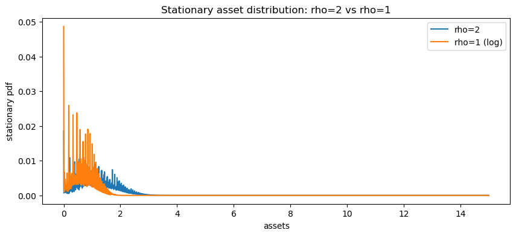

```python
# --- Helper: solve the HH problem + stationary distribution for a given rho ---
def solve_hh(rho_val, bigR_val, w_val, grid_points_val=2000, ahat_max_val=15.0, tol_v=1e-4, tol_pdf=1e-7):
    # grids
    ahat_g_val = np.linspace(0.0, ahat_max_val, grid_points_val)
    y_g_val = w_val * l_g
    ytilde_g_val = y_g_val - (bigR_val - 1) * phi

    # utility
    if rho_val == 1:
        def u_local(c):
            return np.log(c)
    else:
        def u_local(c):
            return c ** (1 - rho_val) / (1 - rho_val)

    # value iteration (same monotone/concave search idea, but in pure python for flexibility)
    v0 = np.zeros((grid_points_val, n))
    v1 = np.empty_like(v0)
    pol = np.empty((grid_points_val, n), dtype=np.int32)
    beta_v_exp = np.empty_like(v0)

    while True:
        # expected value term
        for s in range(n):
            for i in range(grid_points_val):
                beta_v_exp[i,s] = beta * np.dot(p[s,:], v0[i,:])
        dist = 0.0
        for s in range(n):
            pol_s = 0
            for i in range(grid_points_val):
                j = pol_s
                started = False
                while j < grid_points_val:
                    c = bigR_val * ahat_g_val[i] + ytilde_g_val[s] - ahat_g_val[j]
                    if c > 0:
                        val = u_local(c) + beta_v_exp[j,s]
                        if not started:
                            vmax = val
                            pol_s = j
                            started = True
                        elif val > vmax:
                            vmax = val
                            pol_s = j
                        else:
                            break
                    j += 1
                v1[i,s] = vmax
                pol[i,s] = pol_s
                dist = max(dist, abs(v1[i,s]-v0[i,s]))
        if dist < tol_v:
            break
        v0, v1 = v1, v0

    # stationary distribution
    pdf0 = np.ones((grid_points_val, n)) / (grid_points_val * n)
    while True:
        pdf1 = np.zeros_like(pdf0)
        for i in range(grid_points_val):
            for s in range(n):
                for sp in range(n):
                    pdf1[pol[i,s], sp] += p[s,sp] * pdf0[i,s]
        if np.max(np.abs(pdf1-pdf0)) < tol_pdf:
            break
        pdf0 = pdf1

    Abar_val = np.sum(ahat_g_val[:,None] * pdf1)
    constrained_val = np.sum(pdf1[pol==0])
    L_val = np.sum(l_g[None,:] * pdf1)  # mean labor supply
    return ahat_g_val, ytilde_g_val, v1, pol, pdf1, Abar_val, constrained_val, L_val

# Solve baseline (rho=2) quickly on a coarser grid and compare to rho=1
ahat2, ytilde2, v2, pol2, pdf2, Abar2, cons2, L2 = solve_hh(2, bigR, w)
ahat1, ytilde1, v1log, pol1log, pdf1log, Abar1, cons1, L1 = solve_hh(1, bigR, w)

print("rho=2:  Abar={:.4f}, constrained={:.4f}, L={:.4f}".format(Abar2, cons2, L2))
print("rho=1:  Abar={:.4f}, constrained={:.4f}, L={:.4f}".format(Abar1, cons1, L1))

# Plot stationary PDFs over assets (coarser grid versions)
pdf_assets2 = np.sum(pdf2, axis=1)
pdf_assets1 = np.sum(pdf1log, axis=1)
plt.figure(figsize=(10,4))
plt.plot(ahat2, pdf_assets2, label="rho=2")
plt.plot(ahat1, pdf_assets1, label="rho=1 (log)")
plt.xlabel("assets")
plt.ylabel("stationary pdf")
plt.title("Stationary asset distribution: rho=2 vs rho=1")
plt.legend();
```

### (g) Total labor supply in the stationary distribution

Compute $\bar L=\sum_s l(s)\Pr(s)$ from the stationary joint distribution.

```python
Lbar = np.sum(l_g[None,:] * pdf_ss)
print("Total (mean) labor supply in the stationary distribution: {:.6f}".format(Lbar))
```

```
Total (mean) labor supply in the stationary distribution: 0.857143
```

### (h) Firm-side mappings $W(R)$ and $K(R)$

With Cobb–Douglas $F=A K^\alpha L^{1-\alpha}$ and depreciation $\delta$, competitive pricing implies $$R = 1 + \alpha A (K/L)^{\alpha-1} - \delta,\qquad w=(1-\alpha)A (K/L)^\alpha.$$ Use $w(1.04)=1$ to pin down $A$.

```python
alpha = 0.36
delta = 0.1

def k_over_l_from_R(R, A_prod):
    return (alpha * A_prod / (R - 1 + delta))**(1/(1-alpha))

def W_of_R(R, A_prod):
    x = k_over_l_from_R(R, A_prod)
    return (1-alpha) * A_prod * (x**alpha)

def K_of_R(R, A_prod, Lbar_val):
    x = k_over_l_from_R(R, A_prod)
    return x * Lbar_val

# Calibrate A_prod from w(R0)=1 at R0=1.04
R0 = 1.04
mpk = R0 - 1 + delta
x0 = alpha / ((1-alpha)*mpk)            # implied K/L from combining wage+MPK at w=1
A_prod = mpk / (alpha * (x0**(alpha-1)))
print("Calibrated production A such that w(1.04)=1:", A_prod)

# sanity check
print("Check w(R0):", W_of_R(R0, A_prod))
```

```
Calibrated production A such that w(1.04)=1: 0.9470698459994971
Check w(R0): 1.0000000000000002
```

### (i) Check whether $R=1.04$ is a stationary general equilibrium

Compute household asset supply $\bar A(R)$ (with wage $w=W(R)$) and compare to firm capital demand $K(R)$.

In a stationary general equilibrium, the asset (capital) market must clear: $$ \bar A(R)=K(R), $$

From the code output at $R=1.04$， the market-clearing gap is $$ \bar A(R)-K(R)=-2.2745<0. $$

Therefore, at $R=1.04$ we have **excess demand for assets/capital** ($K(R)>\bar A(R)$), so **$R=1.04$ is not a stationary general equilibrium interest rate**

```python
# Household asset supply at R0, using wage from firm
w0 = W_of_R(R0, A_prod)
ahatR, ytildeR, vR, polR, pdfR, AbarR, consR, LR = solve_hh(2, R0, w0)
K0 = K_of_R(R0, A_prod, LR)  # use LR from the stationary distribution (should match the Markov stationary L)
print("At R=1.04: w={:.4f}, Abar(R)={:.4f}, K(R)={:.4f}, gap Abar-K={:.4f}".format(w0, AbarR, K0, AbarR-K0))
```

```
At R=1.04: w=1.0000, Abar(R)=1.1694, K(R)=3.4439, gap Abar-K=-2.2745
```

### (j) Compute and plot $\bar A(R)$ and $K(R)$ on a grid; identify the GE interest rate

We compute $\bar A(R)$ by resolving the household problem for each $R$ (updating $w=W(R)$), and plot against $K(R)$. The GE interest rate is where the two curves intersect.

```
Approximate GE R (from sign change / linear interpolation): 1.0497969202756747
```

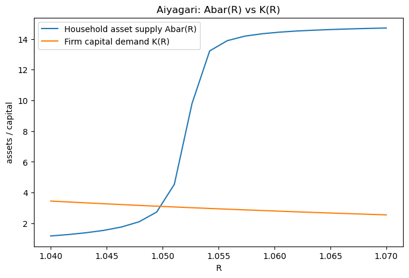

```python
R_grid = np.linspace(1.04, 1.07, 20)
Abar_grid = np.empty_like(R_grid)
K_grid = np.empty_like(R_grid)
w_grid = np.empty_like(R_grid)
L_grid = np.empty_like(R_grid)

for idx,Rval in enumerate(R_grid):
    wval = W_of_R(Rval, A_prod)
    w_grid[idx]=wval
    ahatR, ytildeR, vR, polR, pdfR, AbarR, consR, LR = solve_hh(2, Rval, wval, grid_points_val=1500)
    Abar_grid[idx]=AbarR
    L_grid[idx]=LR
    K_grid[idx]=K_of_R(Rval, A_prod, LR)

plt.figure(figsize=(8,5))
plt.plot(R_grid, Abar_grid, label="Household asset supply Abar(R)")
plt.plot(R_grid, K_grid, label="Firm capital demand K(R)")
plt.xlabel("R")
plt.ylabel("assets / capital")
plt.title("Aiyagari: Abar(R) vs K(R)")
plt.legend();

gap = Abar_grid - K_grid
# find sign change
ge_R = None
for i in range(len(R_grid)-1):
    if gap[i]==0 or gap[i]*gap[i+1] < 0:
        # linear interpolation
        ge_R = R_grid[i] + (R_grid[i+1]-R_grid[i]) * (0-gap[i])/(gap[i+1]-gap[i])
        break
print("Approximate GE R (from sign change / linear interpolation):", ge_R)
```

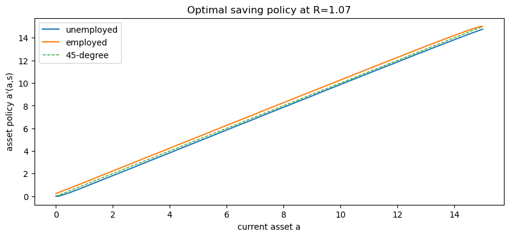

```python
Rval = 1.07
wval = W_of_R(Rval, A_prod)

ahatR, ytildeR, vR, polR, pdfR, AbarR, consR, LR = solve_hh(2, Rval, wval, grid_points_val=1500)

# 用当前 Rval 对应的资产网格和策略
nR = ytildeR.shape[0]
a_prime_a_R = np.empty((ahatR.shape[0], nR))
for s in range(nR):
    a_prime_a_R[:, s] = ahatR[polR[:, s]]

plt.figure(figsize=(10, 4))
labels = ["unemployed", "employed"]  # 如果有更多状态可自行扩展
for s in range(nR):
    lab = labels[s] if s < len(labels) else f"state {s}"
    plt.plot(ahatR, a_prime_a_R[:, s], label=lab)

# 45-degree line: a' = a
plt.plot([ahatR.min(), ahatR.max()],
         [ahatR.min(), ahatR.max()],
         '--', lw=1, label="45-degree")

plt.xlabel("current asset a")
plt.ylabel("asset policy a'(a,s)")
plt.title(f"Optimal saving policy at R={Rval}")
plt.legend()
plt.show()
```